# R Programming Sample

Anumita Jain

2025-08-01

# Introduction

Welcome to my R programming sample!

In this program, I evaluate the effects of NYC’s Pre-K for All program, started in the Fall of 2014, on educational outcomes. I will be employing a difference-in-differences approach to answer my questions, using open source NY state test score data to look at the difference in grades 3-8 ELA and math test scores between students who started 3rd grade without having access to free pre-k (2015 - 2017) and students who started 3rd grade having had access to free pre-k (2018-2019). I stop my analysis at 2019 because the effects of the Covid-19 pandemic on educational outcomes would have been a huge confounding variable.

I will quality check, modify, merge, visualize, and model open source NY state test score data data to answer my questions of 1) whether there is a statistically significant difference in test scores before and after the advent of pre-K for all and 2) whether that difference differs from the difference seen in the state as a whole in that same time period.

# Libraries

```r
library(tidyverse)      # for general programming
library(tigris)         # for school zone shapefiles
library(sf)             # for working with spatial data
library(ggplot2)        # for data visualizations
library(tmap)           # for map visualizations
```

# Import data

## Test score data

```r
# 2015-16
scores_2015_16 <- read_csv("Data/3-8_ELA_AND_MATH_RESEARCHER_FILE_2016.csv")
scores_2015_16 %>% glimpse()
```

```
## Rows: 436,464
## Columns: 23
## $ SY_END_DATE       <chr> "06/30/2016", "06/30/2016", "06/30/2016", "06/30/201…
## $ NRC_CODE          <dbl> NA, NA, NA, NA, NA, NA, NA, NA, NA, NA, NA, NA, NA, …
## $ NRC_DESC          <chr> NA, NA, NA, NA, NA, NA, NA, NA, NA, NA, NA, NA, NA, …
## $ COUNTY_CODE       <chr> NA, NA, NA, NA, NA, NA, NA, NA, NA, NA, NA, NA, NA, …
## $ COUNTY_DESC       <chr> NA, NA, NA, NA, NA, NA, NA, NA, NA, NA, NA, NA, NA, …
## $ BEDSCODE          <chr> "000000000000", "000000000000", "000000000000", "000…
## $ NAME              <chr> "STATEWIDE - ALL DISTRICTS AND CHARTERS", "STATEWIDE…
## $ ITEM_SUBJECT_AREA <chr> "ELA", "ELA", "ELA", "ELA", "ELA", "ELA", "ELA", "EL…
## $ ITEM_DESC         <chr> "Grade 3 ELA", "Grade 3 ELA", "Grade 3 ELA", "Grade …
## $ SUBGROUP_CODE     <chr> "01", "02", "03", "04", "05", "06", "07", "08", "09"…
## $ SUBGROUP_NAME     <chr> "All Students", "Female", "Male", "American Indian o…
## $ TOTAL_TESTED      <chr> "170304", "84064", "86240", "1234", "31899", "49828"…
## $ L1_COUNT          <chr> "45521", "18861", "26660", "388", "11494", "17267", …
## $ L1_PCT            <chr> "27%", "22%", "31%", "31%", "36%", "35%", "14%", "20…
## $ L2_COUNT          <chr> "53393", "25863", "27530", "419", "10466", "17424", …
## $ L2_PCT            <chr> "31%", "31%", "32%", "34%", "33%", "35%", "25%", "30…
## $ L3_COUNT          <chr> "59060", "31514", "27546", "363", "8588", "13441", "…
## $ L3_PCT            <chr> "35%", "37%", "32%", "29%", "27%", "27%", "46%", "41…
## $ L4_COUNT          <chr> "12330", "7826", "4504", "64", "1351", "1696", "2720…
## $ L4_PCT            <chr> "7%", "9%", "5%", "5%", "4%", "3%", "15%", "9%", "9%…
## $ `L2-L4_PCT`       <chr> "73%", "78%", "69%", "69%", "64%", "65%", "86%", "80…
## $ `L3-L4_PCT`       <chr> "42%", "47%", "37%", "35%", "31%", "30%", "61%", "51…
## $ MEAN_SCALE_SCORE  <chr> "309", "314", "305", "304", "300", "301", "324", "31…
```

```r
# 2016-17
scores_2016_17 <- read_csv("Data/3-8_ELA_AND_MATH_RESEARCHER_FILE_2017.csv")
scores_2016_17 %>% glimpse()
```

```
## Rows: 439,657
## Columns: 23
## $ SY_END_DATE       <chr> "06/30/2017", "06/30/2017", "06/30/2017", "06/30/201…
## $ NRC_CODE          <dbl> 7, 7, 7, 7, 7, 7, 7, 7, 7, 7, 7, 7, 7, 7, 7, 7, 7, 7…
## $ NRC_DESC          <chr> "Charters", "Charters", "Charters", "Charters", "Cha…
## $ COUNTY_CODE       <chr> "32", "32", "32", "32", "32", "32", "32", "32", "32"…
## $ COUNTY_DESC       <chr> "BRONX", "BRONX", "BRONX", "BRONX", "BRONX", "BRONX"…
## $ BEDSCODE          <chr> "320700860820", "320700860820", "320700860820", "320…
## $ NAME              <chr> "KIPP ACADEMY CHARTER SCHOOL", "KIPP ACADEMY CHARTER…
## $ ITEM_SUBJECT_AREA <chr> "ELA", "ELA", "ELA", "ELA", "ELA", "Mathematics", "M…
## $ ITEM_DESC         <chr> "Grade 7 ELA", "Grade 7 ELA", "Grade 7 ELA", "Grade …
## $ SUBGROUP_CODE     <chr> "12", "13", "15", "16", "18", "01", "02", "03", "05"…
## $ SUBGROUP_NAME     <chr> "Not English Language Learner", "English Language Le…
## $ TOTAL_TESTED      <chr> "-", "-", "68", "10", "78", "78", "38", "40", "41", …
## $ L1_COUNT          <chr> "-", "-", "4", "0", "4", "10", "3", "7", "5", "-", "…
## $ L1_PCT            <chr> "-", "-", "6%", "0%", "5%", "13%", "8%", "18%", "12%…
## $ L2_COUNT          <chr> "-", "-", "19", "3", "22", "22", "13", "9", "13", "-…
## $ L2_PCT            <chr> "-", "-", "28%", "30%", "28%", "28%", "34%", "23%", …
## $ L3_COUNT          <chr> "-", "-", "37", "4", "41", "30", "18", "12", "15", "…
## $ L3_PCT            <chr> "-", "-", "54%", "40%", "53%", "38%", "47%", "30%", …
## $ L4_COUNT          <chr> "-", "-", "8", "3", "11", "16", "4", "12", "8", "-",…
## $ L4_PCT            <chr> "-", "-", "12%", "30%", "14%", "21%", "11%", "30%", …
## $ `L2-L4_PCT`       <chr> "-", "-", "94%", "100%", "95%", "87%", "92%", "83%",…
## $ `L3-L4_PCT`       <chr> "-", "-", "66%", "70%", "67%", "59%", "58%", "60%", …
## $ MEAN_SCALE_SCORE  <chr> "-", "-", "321", "332", "323", "323", "321", "325", …
```

```r
# 2017-18
scores_2017_18 <- read_csv("Data/3-8_ELA_AND_MATH_RESEARCHER_FILE_2018.csv")
scores_2017_18 %>% glimpse()
```

```
## Rows: 443,603
## Columns: 23
## $ SY_END_DATE       <chr> "06/30/2018", "06/30/2018", "06/30/2018", "06/30/201…
## $ NRC_CODE          <dbl> NA, NA, NA, NA, NA, NA, NA, NA, NA, NA, NA, NA, NA, …
## $ NRC_DESC          <chr> NA, NA, NA, NA, NA, NA, NA, NA, NA, NA, NA, NA, NA, …
## $ COUNTY_CODE       <chr> NA, NA, NA, NA, NA, NA, NA, NA, NA, NA, NA, NA, NA, …
## $ COUNTY_DESC       <chr> NA, NA, NA, NA, NA, NA, NA, NA, NA, NA, NA, NA, NA, …
## $ BEDSCODE          <chr> "000000000000", "000000000000", "000000000000", "000…
## $ NAME              <chr> "STATEWIDE - ALL DISTRICTS AND CHARTERS", "STATEWIDE…
## $ ITEM_SUBJECT_AREA <chr> "ELA", "ELA", "ELA", "ELA", "ELA", "ELA", "ELA", "EL…
## $ ITEM_DESC         <chr> "Grade 3 ELA", "Grade 3 ELA", "Grade 3 ELA", "Grade …
## $ SUBGROUP_CODE     <chr> "01", "02", "03", "04", "05", "06", "07", "08", "09"…
## $ SUBGROUP_NAME     <chr> "All Students", "Female", "Male", "American Indian o…
## $ TOTAL_TESTED      <chr> "173061", "85085", "87976", "1238", "31100", "50275"…
## $ L1_COUNT          <chr> "30787", "12462", "18325", "244", "7658", "11865", "…
## $ L1_PCT            <chr> "18%", "15%", "21%", "20%", "25%", "24%", "8%", "13%…
## $ L2_COUNT          <chr> "54849", "25140", "29709", "451", "10629", "18273", …
## $ L2_PCT            <chr> "32%", "30%", "34%", "36%", "34%", "36%", "22%", "30…
## $ L3_COUNT          <chr> "74885", "39743", "35142", "463", "11257", "18021", …
## $ L3_PCT            <chr> "43%", "47%", "40%", "37%", "36%", "36%", "53%", "49…
## $ L4_COUNT          <chr> "12540", "7740", "4800", "80", "1556", "2116", "2914…
## $ L4_PCT            <chr> "7%", "9%", "5%", "6%", "5%", "4%", "16%", "8%", "9%…
## $ `L2-L4_PCT`       <chr> "82%", "85%", "79%", "80%", "75%", "76%", "92%", "87…
## $ `L3-L4_PCT`       <chr> "51%", "56%", "45%", "44%", "41%", "40%", "70%", "57…
## $ MEAN_SCALE_SCORE  <chr> "600", "603", "597", "598", "595", "595", "609", "60…
```

```r
# 2018-19
scores_2018_19 <- read_csv("Data/3-8_ELA_AND_MATH_RESEARCHER_FILE_2019.csv")
scores_2018_19 %>% glimpse()
```

```
## Rows: 565,818
## Columns: 23
## $ SY_END_DATE       <chr> "6/30/2019", "6/30/2019", "6/30/2019", "6/30/2019", …
## $ NRC_CODE          <dbl> NA, NA, NA, NA, NA, NA, NA, NA, NA, NA, NA, NA, NA, …
## $ NRC_DESC          <chr> NA, NA, NA, NA, NA, NA, NA, NA, NA, NA, NA, NA, NA, …
## $ COUNTY_CODE       <dbl> NA, NA, NA, NA, NA, NA, NA, NA, NA, NA, NA, NA, NA, …
## $ COUNTY_DESC       <chr> NA, NA, NA, NA, NA, NA, NA, NA, NA, NA, NA, NA, NA, …
## $ BEDSCODE          <dbl> 0, 0, 0, 0, 0, 0, 0, 0, 0, 0, 0, 0, 0, 0, 0, 0, 0, 0…
## $ NAME              <chr> "STATEWIDE - ALL DISTRICTS AND CHARTERS", "STATEWIDE…
## $ ITEM_SUBJECT_AREA <chr> "ELA", "ELA", "ELA", "ELA", "ELA", "ELA", "ELA", "EL…
## $ ITEM_DESC         <chr> "Grade 3 ELA", "Grade 3 ELA", "Grade 3 ELA", "Grade …
## $ SUBGROUP_CODE     <dbl> 1, 2, 3, 4, 5, 6, 7, 8, 9, 10, 11, 12, 13, 15, 16, 1…
## $ SUBGROUP_NAME     <chr> "All Students", "Female", "Male", "American Indian o…
## $ TOTAL_TESTED      <chr> "172149", "84744", "87405", "1216", "29834", "50297"…
## $ L1_COUNT          <chr> "26358", "10645", "15713", "187", "6181", "10216", "…
## $ L1_PCT            <chr> "15%", "13%", "18%", "15%", "21%", "20%", "7%", "11%…
## $ L2_COUNT          <chr> "55837", "26224", "29613", "450", "10264", "18514", …
## $ L2_PCT            <chr> "32%", "31%", "34%", "37%", "34%", "37%", "22%", "31…
## $ L3_COUNT          <chr> "77771", "40751", "37020", "499", "11721", "19334", …
## $ L3_PCT            <chr> "45%", "48%", "42%", "41%", "39%", "38%", "55%", "50…
## $ L4_COUNT          <chr> "12183", "7124", "5059", "80", "1668", "2233", "2922…
## $ L4_PCT            <chr> "7%", "8%", "6%", "7%", "6%", "4%", "17%", "7%", "8%…
## $ `L2-L4_PCT`       <chr> "85%", "87%", "82%", "85%", "79%", "80%", "93%", "89…
## $ `L3-L4_PCT`       <chr> "52%", "56%", "48%", "48%", "45%", "43%", "71%", "58…
## $ MEAN_SCALE_SCORE  <chr> "600", "602", "598", "599", "596", "595", "609", "60…
```

## School zones shapefile

In order to create maps later on, I need to read in spatial data of each elementary school’s zone, which I retrieved from NYC Open Data.

```r
zones <- st_read("Data/geo_export_ede36ca7-7cf5-4f8c-aa2b-368d6822b457.shp")
zones %>% glimpse()
```

```
## Rows: 785
## Columns: 16
## $ schooldist <dbl> 21, 21, 21, 21, 21, 21, 22, 22, 16, 21, 21, 21, 21, 21, 15,…
## $ initials   <chr> "BG", "BG", "BG", "BG", "BG", "JG", "BG", "BG", "BG", "BG",…
## $ boro       <chr> "BK", "BK", "BK", "BK", "BK", "BK", "BK", "BK", "BK", "BK",…
## $ creat_date <chr> "08/06/2001", "08/12/2011", "08/12/2011", "08/12/2011", "08…
## $ edit_date  <chr> NA, NA, NA, NA, NA, "12/3/15", "4/5/04", NA, NA, NA, NA, NA…
## $ boro_num   <dbl> 3, 3, 3, 3, 3, 3, 3, 3, 3, 3, 3, 3, 3, 3, 3, 3, 3, 3, 3, 3,…
## $ shape_leng <dbl> 13911.283, 11668.377, 18376.436, 6782.791, 2034.921, 3973.1…
## $ shape_area <dbl> 10480088.3, 3870862.1, 6543570.6, 1833886.2, 212939.9, 6893…
## $ remarks    <chr> NA, NA, NA, NA, NA, "Shared zone: PS 95, PS 97, PS 101, PS …
## $ dbn        <chr> "21K188", "21K288", "21K329", "21K288", "21K329", "21K095,2…
## $ esid_no    <dbl> 117, 118, 120, 121, 122, 128, 1, 2, 75, 124, 125, 126, 133,…
## $ label      <chr> "188", "288", "329", "288", "329", "95, 97, 101, 212, 216",…
## $ zoned_dist <chr> "21", "21", "21", "21", "21", "21", "22", "22", "16", "21",…
## $ x_centroid <dbl> 0, 0, 0, 0, 0, 0, 0, 0, 0, 0, 0, 0, 0, 0, 0, 0, 0, 0, 0, 0,…
## $ y_centroid <dbl> 0, 0, 0, 0, 0, 0, 0, 0, 0, 0, 0, 0, 0, 0, 0, 0, 0, 0, 0, 0,…
## $ geometry   <MULTIPOLYGON [°]> MULTIPOLYGON (((-74.00575 4..., MULTIPOLYGON (…
```

## School location shapefile

Because the school zone data above doesn’t have names associated with it, I also need to read in school point location data that I can then spatially merge with the school zone data to assign a BEDS code to each school zone so that I can merge this spatial data to the numerical test score data.

```r
school_locations <- read_csv("Data/2017_-_2018_School_Locations_20250730.csv")
school_locations %>% glimpse()
```

```
## Rows: 1,823
## Columns: 39
## $ FISCAL_YEAR                       <dbl> 2018, 2018, 2018, 2018, 2018, 2018, …
## $ `ATS SYSTEM CODE`                 <chr> "01M015", "01M019", "01M020", "01M03…
## $ LOCATION_CODE                     <chr> "M015", "M019", "M020", "M034", "M06…
## $ LOCATION_NAME                     <chr> "P.S. 015 Roberto Clemente", "P.S. 0…
## $ `BEDS NUMBER`                     <dbl> 3.101e+11, 3.101e+11, 3.101e+11, 3.1…
## $ MANAGED_BY_NAME                   <chr> "DOE", "DOE", "DOE", "DOE", "DOE", "…
## $ LOCATION_TYPE_DESCRIPTION         <chr> "General Academic", "General Academi…
## $ LOCATION_CATEGORY_DESCRIPTION     <chr> "Elementary", "Elementary", "Element…
## $ GRADES_TEXT                       <chr> "PK,0K,01,02,03,04,05,SE", "PK,0K,01…
## $ GRADES_FINAL_TEXT                 <chr> "PK,0K,01,02,03,04,05", "PK,0K,01,02…
## $ OPEN_DATE                         <chr> "07/01/1904 12:00:00 AM", "07/01/195…
## $ STATUS_DESCRIPTIONS               <chr> "Open", "Open", "Open", "Open", "Ope…
## $ PRIMARY_BUILDING_CODE             <chr> "M015", "M019", "M020", "M034", "M06…
```

[output cut: 26 more lines]

# Data quality check

## 2015-16 Data

This dataset contains state test scores for ELA and math in the 2015-16 school year, broken up by county, school, grade, subject area, and various demographic subgroups.

```r
# Check for full duplicates
scores_2015_16 %>%
  group_by_all() %>%
  filter(n()>1) # 0 rows
```

```
## # A tibble: 0 × 23
## # Groups:   SY_END_DATE, NRC_CODE, NRC_DESC, COUNTY_CODE, COUNTY_DESC,
## #   BEDSCODE, NAME, ITEM_SUBJECT_AREA, ITEM_DESC, SUBGROUP_CODE, SUBGROUP_NAME,
## #   TOTAL_TESTED, L1_COUNT, L1_PCT, L2_COUNT, L2_PCT, L3_COUNT, L3_PCT,
## #   L4_COUNT, L4_PCT, L2-L4_PCT, L3-L4_PCT, MEAN_SCALE_SCORE [0]
## # ℹ 23 variables: SY_END_DATE <chr>, NRC_CODE <dbl>, NRC_DESC <chr>,
## #   COUNTY_CODE <chr>, COUNTY_DESC <chr>, BEDSCODE <chr>, NAME <chr>,
## #   ITEM_SUBJECT_AREA <chr>, ITEM_DESC <chr>, SUBGROUP_CODE <chr>,
## #   SUBGROUP_NAME <chr>, TOTAL_TESTED <chr>, L1_COUNT <chr>, L1_PCT <chr>,
## #   L2_COUNT <chr>, L2_PCT <chr>, L3_COUNT <chr>, L3_PCT <chr>, L4_COUNT <chr>,
## #   L4_PCT <chr>, L2-L4_PCT <chr>, L3-L4_PCT <chr>, MEAN_SCALE_SCORE <chr>
```

```r
# Check for partial duplicates on school/county name, grade/subject, and subgroup name
scores_2015_16 %>%
  group_by(NRC_DESC, COUNTY_DESC, NAME, ITEM_DESC, SUBGROUP_NAME) %>%
  filter(n()>1)# 0 rows
```

```
## # A tibble: 96 × 23
## # Groups:   NRC_DESC, COUNTY_DESC, NAME, ITEM_DESC, SUBGROUP_NAME [48]
##    SY_END_DATE NRC_CODE NRC_DESC  COUNTY_CODE COUNTY_DESC BEDSCODE     NAME
##    <chr>          <dbl> <chr>     <chr>       <chr>       <chr>        <chr>
##  1 06/30/2016         6 Low Needs 28          NASSAU      280203030006 PARKWAY …
##  2 06/30/2016         6 Low Needs 28          NASSAU      280203030006 PARKWAY …
##  3 06/30/2016         6 Low Needs 28          NASSAU      280203030006 PARKWAY …
##  4 06/30/2016         6 Low Needs 28          NASSAU      280203030006 PARKWAY …
##  5 06/30/2016         6 Low Needs 28          NASSAU      280203030006 PARKWAY …
##  6 06/30/2016         6 Low Needs 28          NASSAU      280203030006 PARKWAY …
##  7 06/30/2016         6 Low Needs 28          NASSAU      280203030006 PARKWAY …
##  8 06/30/2016         6 Low Needs 28          NASSAU      280203030006 PARKWAY …
##  9 06/30/2016         6 Low Needs 28          NASSAU      280203030006 PARKWAY …
## 10 06/30/2016         6 Low Needs 28          NASSAU      280203030006 PARKWAY …
## # ℹ 86 more rows
## # ℹ 16 more variables: ITEM_SUBJECT_AREA <chr>, ITEM_DESC <chr>,
## #   SUBGROUP_CODE <chr>, SUBGROUP_NAME <chr>, TOTAL_TESTED <chr>,
## #   L1_COUNT <chr>, L1_PCT <chr>, L2_COUNT <chr>, L2_PCT <chr>, L3_COUNT <chr>,
## #   L3_PCT <chr>, L4_COUNT <chr>, L4_PCT <chr>, `L2-L4_PCT` <chr>,
## #   `L3-L4_PCT` <chr>, MEAN_SCALE_SCORE <chr>
```

```r
# Check for missingness across all columns
colSums(is.na(scores_2015_16))
```

```
##       SY_END_DATE          NRC_CODE          NRC_DESC       COUNTY_CODE
##                 0             11996             11996              1611
##       COUNTY_DESC          BEDSCODE              NAME ITEM_SUBJECT_AREA
##              1611                 0                 0                 0
##         ITEM_DESC     SUBGROUP_CODE     SUBGROUP_NAME      TOTAL_TESTED
##                 0                 0                 0                 0
##          L1_COUNT            L1_PCT          L2_COUNT            L2_PCT
##                 0                 0                 0                 0
##          L3_COUNT            L3_PCT          L4_COUNT            L4_PCT
##                 0                 0                 0                 0
##         L2-L4_PCT         L3-L4_PCT  MEAN_SCALE_SCORE
##                 0                 0                 0
```

There are quite a few partial duplicates that I will look into.

```r
# Check for partial duplicates on school/county name, grade/subject, and subgroup name
scores_2015_16 %>%
  group_by(NRC_DESC, COUNTY_DESC, NAME, ITEM_DESC, SUBGROUP_NAME) %>%
  filter(n()>1) %>%
  arrange(NRC_DESC, COUNTY_DESC, NAME, ITEM_DESC, SUBGROUP_NAME)
```

```
## # A tibble: 96 × 23
## # Groups:   NRC_DESC, COUNTY_DESC, NAME, ITEM_DESC, SUBGROUP_NAME [48]
##    SY_END_DATE NRC_CODE NRC_DESC  COUNTY_CODE COUNTY_DESC BEDSCODE     NAME
##    <chr>          <dbl> <chr>     <chr>       <chr>       <chr>        <chr>
##  1 06/30/2016         6 Low Needs 28          NASSAU      280203030006 PARKWAY …
##  2 06/30/2016         6 Low Needs 28          NASSAU      280504060004 PARKWAY …
##  3 06/30/2016         6 Low Needs 28          NASSAU      280203030006 PARKWAY …
##  4 06/30/2016         6 Low Needs 28          NASSAU      280504060004 PARKWAY …
##  5 06/30/2016         6 Low Needs 28          NASSAU      280203030006 PARKWAY …
##  6 06/30/2016         6 Low Needs 28          NASSAU      280504060004 PARKWAY …
##  7 06/30/2016         6 Low Needs 28          NASSAU      280203030006 PARKWAY …
##  8 06/30/2016         6 Low Needs 28          NASSAU      280504060004 PARKWAY …
##  9 06/30/2016         6 Low Needs 28          NASSAU      280203030006 PARKWAY …
## 10 06/30/2016         6 Low Needs 28          NASSAU      280504060004 PARKWAY …
## # ℹ 86 more rows
## # ℹ 16 more variables: ITEM_SUBJECT_AREA <chr>, ITEM_DESC <chr>,
## #   SUBGROUP_CODE <chr>, SUBGROUP_NAME <chr>, TOTAL_TESTED <chr>,
## #   L1_COUNT <chr>, L1_PCT <chr>, L2_COUNT <chr>, L2_PCT <chr>, L3_COUNT <chr>,
## #   L3_PCT <chr>, L4_COUNT <chr>, L4_PCT <chr>, `L2-L4_PCT` <chr>,
## #   `L3-L4_PCT` <chr>, MEAN_SCALE_SCORE <chr>
```

All of these cases are in one school in Nassau County that has two different BEDS (Basic Educational Data System) codes. Since Nassau County is outside of New York City, it will not be a part of my analysis so I will not look into this further.

There were also quite a few rows with missing counties. I will look at these cases.

```r
scores_2015_16 %>% filter(is.na(COUNTY_CODE) | is.na(COUNTY_DESC)) %>% count(NAME)
```

```
## # A tibble: 8 × 2
##   NAME                                            n
##   <chr>                                       <int>
## 1 NRC - AVERAGE NEEDS                           204
## 2 NRC - BUFFALO, ROCHESTER, YONKERS, SYRACUSE   204
## 3 NRC - CHARTERS                                196
## 4 NRC - LOW NEEDS                               203
## 5 NRC - NYC                                     192
## 6 NRC - RURAL HIGH NEEDS                        204
## 7 NRC - URBAN-SUBURBAN HIGH NEEDS               204
## 8 STATEWIDE - ALL DISTRICTS AND CHARTERS        204
```

For all of these cases, it makes sense not to have a county code/name.

## 2016-17 Data

This dataset contains state test scores for ELA and math in the 2016-17 school year, broken up by county, school, grade, subject area, and various demographic subgroups.

```r
# Check for full duplicates
scores_2016_17 %>%
  group_by_all() %>%
  filter(n()>1) # 0 rows
```

```
## # A tibble: 0 × 23
## # Groups:   SY_END_DATE, NRC_CODE, NRC_DESC, COUNTY_CODE, COUNTY_DESC,
## #   BEDSCODE, NAME, ITEM_SUBJECT_AREA, ITEM_DESC, SUBGROUP_CODE, SUBGROUP_NAME,
## #   TOTAL_TESTED, L1_COUNT, L1_PCT, L2_COUNT, L2_PCT, L3_COUNT, L3_PCT,
## #   L4_COUNT, L4_PCT, L2-L4_PCT, L3-L4_PCT, MEAN_SCALE_SCORE [0]
## # ℹ 23 variables: SY_END_DATE <chr>, NRC_CODE <dbl>, NRC_DESC <chr>,
## #   COUNTY_CODE <chr>, COUNTY_DESC <chr>, BEDSCODE <chr>, NAME <chr>,
## #   ITEM_SUBJECT_AREA <chr>, ITEM_DESC <chr>, SUBGROUP_CODE <chr>,
## #   SUBGROUP_NAME <chr>, TOTAL_TESTED <chr>, L1_COUNT <chr>, L1_PCT <chr>,
## #   L2_COUNT <chr>, L2_PCT <chr>, L3_COUNT <chr>, L3_PCT <chr>, L4_COUNT <chr>,
## #   L4_PCT <chr>, L2-L4_PCT <chr>, L3-L4_PCT <chr>, MEAN_SCALE_SCORE <chr>
```

```r
# Check for partial duplicates on school/county name, grade/subject, and subgroup name
scores_2016_17 %>%
  group_by(NRC_DESC, COUNTY_DESC, NAME, ITEM_DESC, SUBGROUP_NAME) %>%
  filter(n()>1) # 0 rows
```

```
## # A tibble: 0 × 23
## # Groups:   NRC_DESC, COUNTY_DESC, NAME, ITEM_DESC, SUBGROUP_NAME [0]
## # ℹ 23 variables: SY_END_DATE <chr>, NRC_CODE <dbl>, NRC_DESC <chr>,
## #   COUNTY_CODE <chr>, COUNTY_DESC <chr>, BEDSCODE <chr>, NAME <chr>,
## #   ITEM_SUBJECT_AREA <chr>, ITEM_DESC <chr>, SUBGROUP_CODE <chr>,
## #   SUBGROUP_NAME <chr>, TOTAL_TESTED <chr>, L1_COUNT <chr>, L1_PCT <chr>,
## #   L2_COUNT <chr>, L2_PCT <chr>, L3_COUNT <chr>, L3_PCT <chr>, L4_COUNT <chr>,
## #   L4_PCT <chr>, L2-L4_PCT <chr>, L3-L4_PCT <chr>, MEAN_SCALE_SCORE <chr>
```

```r
# Check for missingness across all columns
colSums(is.na(scores_2016_17))
```

```
##       SY_END_DATE          NRC_CODE          NRC_DESC       COUNTY_CODE
##                 0             12029             12029              1607
##       COUNTY_DESC          BEDSCODE              NAME ITEM_SUBJECT_AREA
##              1607                 0                 0                 0
##         ITEM_DESC     SUBGROUP_CODE     SUBGROUP_NAME      TOTAL_TESTED
##                 0                 0                 0                 0
##          L1_COUNT            L1_PCT          L2_COUNT            L2_PCT
##                 0                 0                 0                 0
##          L3_COUNT            L3_PCT          L4_COUNT            L4_PCT
##                 0                 0                 0                 0
##         L2-L4_PCT         L3-L4_PCT  MEAN_SCALE_SCORE
##                 0                 0                 0
```

Everything looks good here but I will once again check in on the county missingness situation.

```r
scores_2016_17 %>% filter(is.na(COUNTY_CODE) | is.na(COUNTY_DESC)) %>% count(NAME)
```

```
## # A tibble: 8 × 2
##   NAME                                            n
##   <chr>                                       <int>
## 1 NRC - AVERAGE NEEDS                           204
## 2 NRC - BUFFALO, ROCHESTER, YONKERS, SYRACUSE   204
## 3 NRC - CHARTERS                                192
## 4 NRC - LOW NEEDS                               203
## 5 NRC - NYC                                     192
## 6 NRC - RURAL HIGH NEEDS                        204
## 7 NRC - URBAN-SUBURBAN HIGH NEEDS               204
## 8 STATEWIDE - ALL DISTRICTS AND CHARTERS        204
```

It’s the same situation as earlier, and there is no cause for concern.

## 2017-18 Data

This dataset contains state test scores for ELA and math in the 2017-18 school year, broken up by county, school, grade, subject area, and various demographic subgroups.

```r
# Check for full duplicates
scores_2017_18 %>%
  group_by_all() %>%
  filter(n()>1) # 0 rows
```

```
## # A tibble: 0 × 23
## # Groups:   SY_END_DATE, NRC_CODE, NRC_DESC, COUNTY_CODE, COUNTY_DESC,
## #   BEDSCODE, NAME, ITEM_SUBJECT_AREA, ITEM_DESC, SUBGROUP_CODE, SUBGROUP_NAME,
## #   TOTAL_TESTED, L1_COUNT, L1_PCT, L2_COUNT, L2_PCT, L3_COUNT, L3_PCT,
## #   L4_COUNT, L4_PCT, L2-L4_PCT, L3-L4_PCT, MEAN_SCALE_SCORE [0]
## # ℹ 23 variables: SY_END_DATE <chr>, NRC_CODE <dbl>, NRC_DESC <chr>,
## #   COUNTY_CODE <chr>, COUNTY_DESC <chr>, BEDSCODE <chr>, NAME <chr>,
## #   ITEM_SUBJECT_AREA <chr>, ITEM_DESC <chr>, SUBGROUP_CODE <chr>,
## #   SUBGROUP_NAME <chr>, TOTAL_TESTED <chr>, L1_COUNT <chr>, L1_PCT <chr>,
## #   L2_COUNT <chr>, L2_PCT <chr>, L3_COUNT <chr>, L3_PCT <chr>, L4_COUNT <chr>,
## #   L4_PCT <chr>, L2-L4_PCT <chr>, L3-L4_PCT <chr>, MEAN_SCALE_SCORE <chr>
```

```r
# Check for partial duplicates on school/county name, grade/subject, and subgroup name
scores_2017_18 %>%
  group_by(NRC_DESC, COUNTY_DESC, NAME, ITEM_DESC, SUBGROUP_NAME) %>%
  filter(n()>1) # 0 rows
```

```
## # A tibble: 0 × 23
## # Groups:   NRC_DESC, COUNTY_DESC, NAME, ITEM_DESC, SUBGROUP_NAME [0]
## # ℹ 23 variables: SY_END_DATE <chr>, NRC_CODE <dbl>, NRC_DESC <chr>,
## #   COUNTY_CODE <chr>, COUNTY_DESC <chr>, BEDSCODE <chr>, NAME <chr>,
## #   ITEM_SUBJECT_AREA <chr>, ITEM_DESC <chr>, SUBGROUP_CODE <chr>,
## #   SUBGROUP_NAME <chr>, TOTAL_TESTED <chr>, L1_COUNT <chr>, L1_PCT <chr>,
## #   L2_COUNT <chr>, L2_PCT <chr>, L3_COUNT <chr>, L3_PCT <chr>, L4_COUNT <chr>,
## #   L4_PCT <chr>, L2-L4_PCT <chr>, L3-L4_PCT <chr>, MEAN_SCALE_SCORE <chr>
```

```r
# Check for missingness across all columns
colSums(is.na(scores_2017_18))
```

```
##       SY_END_DATE          NRC_CODE          NRC_DESC       COUNTY_CODE
##                 0             12031             12031              1608
##       COUNTY_DESC          BEDSCODE              NAME ITEM_SUBJECT_AREA
##              1608                 0                 0                 0
##         ITEM_DESC     SUBGROUP_CODE     SUBGROUP_NAME      TOTAL_TESTED
##                 0                 0                 0                 0
##          L1_COUNT            L1_PCT          L2_COUNT            L2_PCT
##                 0                 0                 0                 0
##          L3_COUNT            L3_PCT          L4_COUNT            L4_PCT
##                 0                 0                 0                 0
##         L2-L4_PCT         L3-L4_PCT  MEAN_SCALE_SCORE
##                 0                 0                 0
```

Everything looks good here but I will once again check in on the county missingness situation.

```r
scores_2017_18 %>% filter(is.na(COUNTY_CODE) | is.na(COUNTY_DESC)) %>% count(NAME)
```

```
## # A tibble: 8 × 2
##   NAME                                            n
##   <chr>                                       <int>
## 1 NRC - AVERAGE NEEDS                           204
## 2 NRC - BUFFALO, ROCHESTER, YONKERS, SYRACUSE   204
## 3 NRC - CHARTERS                                192
## 4 NRC - LOW NEEDS                               204
## 5 NRC - NYC                                     192
## 6 NRC - RURAL HIGH NEEDS                        204
## 7 NRC - URBAN-SUBURBAN HIGH NEEDS               204
## 8 STATEWIDE - ALL DISTRICTS AND CHARTERS        204
```

It’s the same situation as earlier, and there is no cause for concern.

## 2018-19 Data

This dataset contains state test scores for ELA and math in the 2018-19 school year, broken up by county, school, grade, subject area, and various demographic subgroups.

```r
# Check for full duplicates
scores_2018_19 %>%
  group_by_all() %>%
  filter(n()>1) # 0 rows
```

```
## # A tibble: 0 × 23
## # Groups:   SY_END_DATE, NRC_CODE, NRC_DESC, COUNTY_CODE, COUNTY_DESC,
## #   BEDSCODE, NAME, ITEM_SUBJECT_AREA, ITEM_DESC, SUBGROUP_CODE, SUBGROUP_NAME,
## #   TOTAL_TESTED, L1_COUNT, L1_PCT, L2_COUNT, L2_PCT, L3_COUNT, L3_PCT,
## #   L4_COUNT, L4_PCT, L2-L4_PCT, L3-L4_PCT, MEAN_SCALE_SCORE [0]
## # ℹ 23 variables: SY_END_DATE <chr>, NRC_CODE <dbl>, NRC_DESC <chr>,
## #   COUNTY_CODE <dbl>, COUNTY_DESC <chr>, BEDSCODE <dbl>, NAME <chr>,
## #   ITEM_SUBJECT_AREA <chr>, ITEM_DESC <chr>, SUBGROUP_CODE <dbl>,
## #   SUBGROUP_NAME <chr>, TOTAL_TESTED <chr>, L1_COUNT <chr>, L1_PCT <chr>,
## #   L2_COUNT <chr>, L2_PCT <chr>, L3_COUNT <chr>, L3_PCT <chr>, L4_COUNT <chr>,
## #   L4_PCT <chr>, L2-L4_PCT <chr>, L3-L4_PCT <chr>, MEAN_SCALE_SCORE <chr>
```

```r
# Check for partial duplicates on school/county name, grade/subject, and subgroup name
scores_2018_19 %>%
  group_by(NRC_DESC, COUNTY_DESC, NAME, ITEM_DESC, SUBGROUP_NAME) %>%
  filter(n()>1) # 0 rows
```

```
## # A tibble: 0 × 23
## # Groups:   NRC_DESC, COUNTY_DESC, NAME, ITEM_DESC, SUBGROUP_NAME [0]
## # ℹ 23 variables: SY_END_DATE <chr>, NRC_CODE <dbl>, NRC_DESC <chr>,
## #   COUNTY_CODE <dbl>, COUNTY_DESC <chr>, BEDSCODE <dbl>, NAME <chr>,
## #   ITEM_SUBJECT_AREA <chr>, ITEM_DESC <chr>, SUBGROUP_CODE <dbl>,
## #   SUBGROUP_NAME <chr>, TOTAL_TESTED <chr>, L1_COUNT <chr>, L1_PCT <chr>,
## #   L2_COUNT <chr>, L2_PCT <chr>, L3_COUNT <chr>, L3_PCT <chr>, L4_COUNT <chr>,
## #   L4_PCT <chr>, L2-L4_PCT <chr>, L3-L4_PCT <chr>, MEAN_SCALE_SCORE <chr>
```

```r
# Check for missingness across all columns
colSums(is.na(scores_2018_19))
```

```
##       SY_END_DATE          NRC_CODE          NRC_DESC       COUNTY_CODE
##                 0             15938             15938              2148
##       COUNTY_DESC          BEDSCODE              NAME ITEM_SUBJECT_AREA
##              2148                 0                 0                 0
##         ITEM_DESC     SUBGROUP_CODE     SUBGROUP_NAME      TOTAL_TESTED
##                 0                 0                 0                 0
##          L1_COUNT            L1_PCT          L2_COUNT            L2_PCT
##                 0                 0                 0                 0
##          L3_COUNT            L3_PCT          L4_COUNT            L4_PCT
##                 0                 0                 0                 0
##         L2-L4_PCT         L3-L4_PCT  MEAN_SCALE_SCORE
##                 0                 0                 0
```

Everything looks good here but I will once again check in on the county missingness situation.

```r
scores_2018_19 %>% filter(is.na(COUNTY_CODE) | is.na(COUNTY_DESC)) %>% count(NAME)
```

```
## # A tibble: 8 × 2
##   NAME                                            n
##   <chr>                                       <int>
## 1 NRC - AVERAGE NEEDS                           276
## 2 NRC - BUFFALO, ROCHESTER, YONKERS, SYRACUSE   268
## 3 NRC - CHARTERS                                260
## 4 NRC - LOW NEEDS                               276
## 5 NRC - NYC                                     240
## 6 NRC - RURAL HIGH NEEDS                        276
## 7 NRC - URBAN-SUBURBAN HIGH NEEDS               276
## 8 STATEWIDE - ALL DISTRICTS AND CHARTERS        276
```

It’s the same situation as earlier, and there is no cause for concern.

## School zone spatial data

```r
# Check for full duplicates
zones %>%
  group_by_all() %>%
  filter(n()>1) # 0 rows
```

```
## Simple feature collection with 0 features and 15 fields
## Bounding box:  xmin: NA ymin: NA xmax: NA ymax: NA
## Geodetic CRS:  WGS 84
## # A tibble: 0 × 16
## # Groups:   schooldist, initials, boro, creat_date, edit_date, boro_num,
## #   shape_leng, shape_area, remarks, dbn, esid_no, label, zoned_dist,
## #   x_centroid, y_centroid, geometry [0]
## # ℹ 16 variables: schooldist <dbl>, initials <chr>, boro <chr>,
## #   creat_date <chr>, edit_date <chr>, boro_num <dbl>, shape_leng <dbl>,
## #   shape_area <dbl>, remarks <chr>, dbn <chr>, esid_no <dbl>, label <chr>,
## #   zoned_dist <chr>, x_centroid <dbl>, y_centroid <dbl>,
## #   geometry <GEOMETRY [°]>
```

```r
# Check for partial duplicates on internal ID number
zones %>%
  group_by(esid_no) %>%
  filter(n()>1) # 0 rows
```

```
## Simple feature collection with 0 features and 15 fields
## Bounding box:  xmin: NA ymin: NA xmax: NA ymax: NA
## Geodetic CRS:  WGS 84
## # A tibble: 0 × 16
## # Groups:   esid_no [0]
## # ℹ 16 variables: schooldist <dbl>, initials <chr>, boro <chr>,
## #   creat_date <chr>, edit_date <chr>, boro_num <dbl>, shape_leng <dbl>,
## #   shape_area <dbl>, remarks <chr>, dbn <chr>, esid_no <dbl>, label <chr>,
## #   zoned_dist <chr>, x_centroid <dbl>, y_centroid <dbl>,
## #   geometry <GEOMETRY [°]>
```

```r
# Check for missingness across all columns
colSums(is.na(zones))
```

```
## schooldist   initials       boro creat_date  edit_date   boro_num shape_leng
##          0         11          1         18        442          0          0
## shape_area    remarks        dbn    esid_no      label zoned_dist x_centroid
##          0        662         31          0         29          0          0
## y_centroid   geometry
##          0          0
```

There is no missingness in geometry, which is the only variable I’ll be using.

## School location data

```r
# Check for full duplicates
school_locations %>%
  group_by_all() %>%
  filter(n()>1) # 0 rows
```

```
## # A tibble: 0 × 39
## # Groups:   FISCAL_YEAR, ATS SYSTEM CODE, LOCATION_CODE, LOCATION_NAME, BEDS
## #   NUMBER, MANAGED_BY_NAME, LOCATION_TYPE_DESCRIPTION,
## #   LOCATION_CATEGORY_DESCRIPTION, GRADES_TEXT, GRADES_FINAL_TEXT, OPEN_DATE,
## #   STATUS_DESCRIPTIONS, PRIMARY_BUILDING_CODE, PRIMARY_ADDRESS_LINE_1,
## #   STATE_CODE, X_COORDINATE, Y_COORDINATE, COMMUNITY_DISTRICT,
## #   COUNCIL_DISTRICT, CENSUS_TRACT, BOROUGH_BLOCK_LOT, NTA, NTA_NAME,
## #   PRINCIPAL_NAME, PRINCIPAL_TITLE, PRINCIPAL_PHONE_NUMBER, FAX_NUMBER,
## #   GEOGRAPHICAL_DISTRICT_CODE, ADMIN_DISTRICT_LOCATION_CODE,
## #   ADMINISTRATIVE_DISTRICT_NAME, COMMUNITY_SCHOOL_SUP_NAME,
## #   FIELD_SUPPORT_CENTER_NAME, FIELD_SUPPORT_CENTER_LEADER_NAME,
## #   SCHOOL_SUPPORT_TEAM_NAME, SCHOOL_SUPPORT_TEAM_LEADER_NAME,
## #   HIGHSCHOOL_NETWORK_LOCATION_CODE, HIGHSCHOOL_NETWORK_NAME,
## #   HIGHSCHOOL_NETWORK_SUPERINTENDENT, Location 1 [0]
## # ℹ 39 variables: FISCAL_YEAR <dbl>, ATS SYSTEM CODE <chr>,
## #   LOCATION_CODE <chr>, LOCATION_NAME <chr>, BEDS NUMBER <dbl>,
## #   MANAGED_BY_NAME <chr>, LOCATION_TYPE_DESCRIPTION <chr>,
## #   LOCATION_CATEGORY_DESCRIPTION <chr>, GRADES_TEXT <chr>,
## #   GRADES_FINAL_TEXT <chr>, OPEN_DATE <chr>, STATUS_DESCRIPTIONS <chr>,
## #   PRIMARY_BUILDING_CODE <chr>, PRIMARY_ADDRESS_LINE_1 <chr>,
## #   STATE_CODE <chr>, X_COORDINATE <dbl>, Y_COORDINATE <dbl>, …
```

```r
# Check for partial duplicates on BEDS code
school_locations %>%
  group_by(`BEDS NUMBER`) %>%
  filter(n()>1) # 0 rows
```

```
## # A tibble: 0 × 39
## # Groups:   BEDS NUMBER [0]
## # ℹ 39 variables: FISCAL_YEAR <dbl>, ATS SYSTEM CODE <chr>,
## #   LOCATION_CODE <chr>, LOCATION_NAME <chr>, BEDS NUMBER <dbl>,
## #   MANAGED_BY_NAME <chr>, LOCATION_TYPE_DESCRIPTION <chr>,
## #   LOCATION_CATEGORY_DESCRIPTION <chr>, GRADES_TEXT <chr>,
## #   GRADES_FINAL_TEXT <chr>, OPEN_DATE <chr>, STATUS_DESCRIPTIONS <chr>,
## #   PRIMARY_BUILDING_CODE <chr>, PRIMARY_ADDRESS_LINE_1 <chr>,
## #   STATE_CODE <chr>, X_COORDINATE <dbl>, Y_COORDINATE <dbl>, …
```

```r
# Check for missingness across all columns
colSums(is.na(school_locations))
```

```
##                       FISCAL_YEAR                   ATS SYSTEM CODE
##                                 0                                 0
##                     LOCATION_CODE                     LOCATION_NAME
##                                 0                                 0
##                       BEDS NUMBER                   MANAGED_BY_NAME
##                                 0                                 0
##         LOCATION_TYPE_DESCRIPTION     LOCATION_CATEGORY_DESCRIPTION
##                                 0                                 0
##                       GRADES_TEXT                 GRADES_FINAL_TEXT
##                                 0                                17
##                         OPEN_DATE               STATUS_DESCRIPTIONS
##                                 0                                 0
##             PRIMARY_BUILDING_CODE            PRIMARY_ADDRESS_LINE_1
##                                 0                                 0
##                        STATE_CODE                      X_COORDINATE
##                                 0                                 1
##                      Y_COORDINATE                COMMUNITY_DISTRICT
##                                 1                                 0
##                  COUNCIL_DISTRICT                      CENSUS_TRACT
##                                 0                                 1
##                 BOROUGH_BLOCK_LOT                               NTA
##                                 0                                 1
##                          NTA_NAME                    PRINCIPAL_NAME
##                                 1                                 0
##                   PRINCIPAL_TITLE            PRINCIPAL_PHONE_NUMBER
##                                 0                                 0
##                        FAX_NUMBER        GEOGRAPHICAL_DISTRICT_CODE
##                                 0                                 0
##      ADMIN_DISTRICT_LOCATION_CODE      ADMINISTRATIVE_DISTRICT_NAME
##                                 0                                 0
##         COMMUNITY_SCHOOL_SUP_NAME         FIELD_SUPPORT_CENTER_NAME
##                                 0                                 0
##  FIELD_SUPPORT_CENTER_LEADER_NAME          SCHOOL_SUPPORT_TEAM_NAME
##                                 0                                 0
##   SCHOOL_SUPPORT_TEAM_LEADER_NAME  HIGHSCHOOL_NETWORK_LOCATION_CODE
##                                 0                                 0
##           HIGHSCHOOL_NETWORK_NAME HIGHSCHOOL_NETWORK_SUPERINTENDENT
##                                 0                                 0
##                        Location 1
##                                 1
```

The only variables I will be using from this dataset are BEDS code (0 missing rows) and location (1 missing row). I’m going to look into the one row that’s missing its location.

```r
school_locations %>% filter(is.na(`Location 1`))
```

```
## # A tibble: 1 × 39
##   FISCAL_YEAR `ATS SYSTEM CODE` LOCATION_CODE LOCATION_NAME `BEDS NUMBER`
##         <dbl> <chr>             <chr>         <chr>                 <dbl>
## 1        2018 75Q256            Q256          P.S. Q256      307500014256
## # ℹ 34 more variables: MANAGED_BY_NAME <chr>, LOCATION_TYPE_DESCRIPTION <chr>,
## #   LOCATION_CATEGORY_DESCRIPTION <chr>, GRADES_TEXT <chr>,
## #   GRADES_FINAL_TEXT <chr>, OPEN_DATE <chr>, STATUS_DESCRIPTIONS <chr>,
## #   PRIMARY_BUILDING_CODE <chr>, PRIMARY_ADDRESS_LINE_1 <chr>,
## #   STATE_CODE <chr>, X_COORDINATE <dbl>, Y_COORDINATE <dbl>,
## #   COMMUNITY_DISTRICT <dbl>, COUNCIL_DISTRICT <dbl>, CENSUS_TRACT <dbl>,
## #   BOROUGH_BLOCK_LOT <dbl>, NTA <chr>, NTA_NAME <chr>, PRINCIPAL_NAME <chr>, …
```

A quick Google search reveals that this school (and its listed address) is located in Syosset, NY, outside of NYC city limits. Because it is not a part of my analysis, I will ignore this.

# Prepare data for analysis

## Subset test score data to NYC and 3rd grade

Since my analysis is focused on New York City and this data includes schools statewide, I will now subset the data to only include rows involving New York City (as well as rows pertaining to the entire state, for the difference-in-differences evaluation later). In addition, I will only be looking at 3rd grade test scores as that is the only grade that will have had access to Pre-K for All in the final year I am looking at in this analysis (2018-19 school year).

```r
# 2015-16
nyc_2015_16 <- scores_2015_16 %>%

  # filter to NYC and NY state whole population
  filter(NAME == "NRC - NYC" | NAME == "STATEWIDE - ALL DISTRICTS AND CHARTERS" | COUNTY_DESC=="NEW YORK" | COUNTY_DESC=="KINGS" | COUNTY_DESC=="QUEENS" | COUNTY_DESC=="BRONX" | COUNTY_DESC=="RICHMOND") %>%

  # filter to 3rd grade
  filter(grepl("Grade 3", ITEM_DESC))

# check county names
nyc_2015_16 %>% count(COUNTY_DESC)
```

```
## # A tibble: 6 × 2
##   COUNTY_DESC     n
##   <chr>       <int>
## 1 BRONX        5475
## 2 KINGS        8343
## 3 NEW YORK     4699
## 4 QUEENS       6074
## 5 RICHMOND     1429
## 6 <NA>           66
```

```r
nyc_2015_16 %>% filter(is.na(COUNTY_DESC)) %>% count(NAME)
```

```
## # A tibble: 2 × 2
##   NAME                                       n
##   <chr>                                  <int>
## 1 NRC - NYC                                 32
## 2 STATEWIDE - ALL DISTRICTS AND CHARTERS    34
```

```r
# check grades
nyc_2015_16 %>% count(ITEM_DESC)
```

```
## # A tibble: 2 × 2
##   ITEM_DESC        n
##   <chr>        <int>
## 1 Grade 3 ELA  13023
## 2 Grade 3 Math 13063
```

```r
# 2016-17
nyc_2016_17 <- scores_2016_17 %>%

  # filter to NYC and NY state whole population
  filter(NAME == "NRC - NYC" | NAME == "STATEWIDE - ALL DISTRICTS AND CHARTERS" | COUNTY_DESC=="NEW YORK" | COUNTY_DESC=="KINGS" | COUNTY_DESC=="QUEENS" | COUNTY_DESC=="BRONX" | COUNTY_DESC=="RICHMOND") %>%

  # filter to 3rd grade
  filter(grepl("Grade 3", ITEM_DESC))

# check county names
nyc_2016_17 %>% count(COUNTY_DESC)
```

```
## # A tibble: 6 × 2
##   COUNTY_DESC     n
##   <chr>       <int>
## 1 BRONX        5609
## 2 KINGS        8683
## 3 NEW YORK     4759
## 4 QUEENS       6215
## 5 RICHMOND     1489
## 6 <NA>           66
```

```r
nyc_2016_17 %>% filter(is.na(COUNTY_DESC)) %>% count(NAME)
```

```
## # A tibble: 2 × 2
##   NAME                                       n
##   <chr>                                  <int>
## 1 NRC - NYC                                 32
## 2 STATEWIDE - ALL DISTRICTS AND CHARTERS    34
```

```r
# check grades
nyc_2016_17 %>% count(ITEM_DESC)
```

```
## # A tibble: 2 × 2
##   ITEM_DESC        n
##   <chr>        <int>
## 1 Grade 3 ELA  13407
## 2 Grade 3 Math 13414
```

```r
# 2017-18
nyc_2017_18 <- scores_2017_18 %>%

  # filter to NYC and NY state whole population
  filter(NAME == "NRC - NYC" | NAME == "STATEWIDE - ALL DISTRICTS AND CHARTERS" | COUNTY_DESC=="NEW YORK" | COUNTY_DESC=="KINGS" | COUNTY_DESC=="QUEENS" | COUNTY_DESC=="BRONX" | COUNTY_DESC=="RICHMOND") %>%

  # filter to 3rd grade
  filter(grepl("Grade 3", ITEM_DESC))

# check county names
nyc_2017_18 %>% count(COUNTY_DESC)
```

```
## # A tibble: 6 × 2
##   COUNTY_DESC     n
##   <chr>       <int>
## 1 BRONX        5739
## 2 KINGS        8763
## 3 NEW YORK     4796
## 4 QUEENS       6323
## 5 RICHMOND     1502
## 6 <NA>           66
```

```r
nyc_2017_18 %>% filter(is.na(COUNTY_DESC)) %>% count(NAME)
```

```
## # A tibble: 2 × 2
##   NAME                                       n
##   <chr>                                  <int>
## 1 NRC - NYC                                 32
## 2 STATEWIDE - ALL DISTRICTS AND CHARTERS    34
```

```r
# check grades
nyc_2017_18 %>% count(ITEM_DESC)
```

```
## # A tibble: 2 × 2
##   ITEM_DESC        n
##   <chr>        <int>
## 1 Grade 3 ELA  13594
## 2 Grade 3 Math 13595
```

```r
# 2018-19
nyc_2018_19 <- scores_2018_19 %>%

  # filter to NYC and NY state whole population
  filter(NAME == "NRC - NYC" | NAME == "STATEWIDE - ALL DISTRICTS AND CHARTERS" | COUNTY_DESC=="NEW YORK" | COUNTY_DESC=="KINGS" | COUNTY_DESC=="QUEENS" | COUNTY_DESC=="BRONX" | COUNTY_DESC=="RICHMOND") %>%

  # filter to 3rd grade
  filter(grepl("Grade 3", ITEM_DESC)) %>%

  # add leading zeroes to BEDS code and subgroup code variables
  mutate(BEDSCODE = case_when(NAME=="NEW YORK COUNTY" ~ "310000000000",
                              TRUE ~ str_pad(BEDSCODE, width = 12, side = "left", pad = "0")),
         SUBGROUP_CODE = str_pad(SUBGROUP_CODE, width = 2, side = "left", pad = "0"))

# check county names
nyc_2018_19 %>% count(COUNTY_DESC)
```

```
## # A tibble: 6 × 2
##   COUNTY_DESC     n
##   <chr>       <int>
## 1 BRONX        7439
## 2 KINGS       11046
## 3 NEW YORK     6103
## 4 QUEENS       8173
## 5 RICHMOND     1919
## 6 <NA>           86
```

```r
nyc_2018_19 %>% filter(is.na(COUNTY_DESC)) %>% count(NAME)
```

```
## # A tibble: 2 × 2
##   NAME                                       n
##   <chr>                                  <int>
## 1 NRC - NYC                                 40
## 2 STATEWIDE - ALL DISTRICTS AND CHARTERS    46
```

```r
# check grades
nyc_2018_19 %>% count(ITEM_DESC)
```

```
## # A tibble: 2 × 2
##   ITEM_DESC        n
##   <chr>        <int>
## 1 Grade 3 ELA  17370
## 2 Grade 3 Math 17396
```

## Stack test score datasets

I will now stack the four datasets to facilitate visualization and modeling later on.

```r
nyc_15t19 <- rbind(nyc_2015_16, nyc_2016_17, nyc_2017_18, nyc_2018_19)

# check that row counts are as expected
isTRUE(nyc_15t19 %>% nrow() == nyc_2015_16 %>% nrow() + nyc_2016_17 %>% nrow() + nyc_2017_18 %>% nrow() + nyc_2018_19 %>% nrow())
```

```
## [1] TRUE
```

```r
# check that school year end dates make sense
nyc_15t19 %>% count(SY_END_DATE)
```

```
## # A tibble: 4 × 2
##   SY_END_DATE     n
##   <chr>       <int>
## 1 06/30/2016  26086
## 2 06/30/2017  26821
## 3 06/30/2018  27189
## 4 6/30/2019   34766
```

## Pivot test score data

I am going to pivot this dataset so that there is one column per year and variable for each unit (in this case a unit is the entire city, a county, or a school).

```r
# select only relevant variables
nyc_15t19_subset <- nyc_15t19 %>%

  # select only relevant variables
  select(SY_END_DATE, NRC_CODE, NRC_DESC, COUNTY_CODE, COUNTY_DESC, BEDSCODE, NAME, ITEM_SUBJECT_AREA, ITEM_DESC, SUBGROUP_CODE, SUBGROUP_NAME, L1_PCT, L2_PCT, L3_PCT, L4_PCT, `L3-L4_PCT`, MEAN_SCALE_SCORE) %>%

  # convert variables to numeric
  mutate(L1_PCT = as.numeric(gsub("%", "", L1_PCT)),
         L2_PCT = as.numeric(gsub("%", "", L2_PCT)),
         L3_PCT = as.numeric(gsub("%", "", L3_PCT)),
         L4_PCT = as.numeric(gsub("%", "", L4_PCT)),
         `L3-L4_PCT` = as.numeric(gsub("%", "", `L3-L4_PCT`)),
         )

# pivot
nyc_15t19_pivot <- nyc_15t19_subset %>% pivot_wider(names_from = SY_END_DATE, values_from = c(L1_PCT, L2_PCT, L3_PCT, L4_PCT, `L3-L4_PCT`, MEAN_SCALE_SCORE))

# peek at dataset
nyc_15t19_pivot # looks good
```

```
## # A tibble: 42,446 × 34
##    NRC_CODE NRC_DESC COUNTY_CODE COUNTY_DESC BEDSCODE    NAME  ITEM_SUBJECT_AREA
##       <dbl> <chr>    <chr>       <chr>       <chr>       <chr> <chr>
##  1       NA <NA>     <NA>        <NA>        0000000000… STAT… ELA
##  2       NA <NA>     <NA>        <NA>        0000000000… STAT… ELA
##  3       NA <NA>     <NA>        <NA>        0000000000… STAT… ELA
##  4       NA <NA>     <NA>        <NA>        0000000000… STAT… ELA
##  5       NA <NA>     <NA>        <NA>        0000000000… STAT… ELA
##  6       NA <NA>     <NA>        <NA>        0000000000… STAT… ELA
##  7       NA <NA>     <NA>        <NA>        0000000000… STAT… ELA
##  8       NA <NA>     <NA>        <NA>        0000000000… STAT… ELA
##  9       NA <NA>     <NA>        <NA>        0000000000… STAT… ELA
## 10       NA <NA>     <NA>        <NA>        0000000000… STAT… ELA
## # ℹ 42,436 more rows
## # ℹ 27 more variables: ITEM_DESC <chr>, SUBGROUP_CODE <chr>,
## #   SUBGROUP_NAME <chr>, `L1_PCT_06/30/2016` <dbl>, `L1_PCT_06/30/2017` <dbl>,
## #   `L1_PCT_06/30/2018` <dbl>, `L1_PCT_6/30/2019` <dbl>,
## #   `L2_PCT_06/30/2016` <dbl>, `L2_PCT_06/30/2017` <dbl>,
## #   `L2_PCT_06/30/2018` <dbl>, `L2_PCT_6/30/2019` <dbl>,
## #   `L3_PCT_06/30/2016` <dbl>, `L3_PCT_06/30/2017` <dbl>, …
```

## Merge school zone data with school location data

### Prepare school location data for merge

The school location data needs to be transformed into a simple features (sf) object. In order to do that, I need its coordinates which are buried in the “Location 1” variable. I’m first going to extract the coordinates from that variable.

```r
# create coordinate variables
school_locations2 <- school_locations %>% mutate(

  # extracting string in parentheses
  coordinates = str_extract(`Location 1`, "\\((.*?)\\)"),

  # extracting string between opening parenthesis and comma
  latitude = str_extract(coordinates,"(?<=\\()[^,]+(?=,)"),

  # extracting string between comma and closing parenthesis
  longitude = str_extract(coordinates, "(?<=,)\\s*([^)]*)\\)"),
  # removing closing parenthesis and space from longitude
  longitude = gsub(")", "", longitude),
  longitude = gsub(" ", "", longitude)) %>%

  # get rid of row with missing coordinates
  filter(!is.na(latitude) & !is.na(longitude) & latitude !="0.0")

# check that coordinates look right
range(school_locations2$latitude)
```

```
## [1] "40.5083"   "40.903275"
```

```r
range(school_locations2$longitude)
```

```
## [1] "-73.708617" "-74.24395"
```

```r
# transform into an sf object
school_locations_sf <- school_locations2 %>% st_as_sf(coords = c("longitude", "latitude"), crs = st_crs(zones))
# make sure geometry is correct
school_locations_sf <- sf::st_make_valid(school_locations_sf)
```

### Merge the spatial datasets

```r
# make sure zones geometry is correct
zones <- st_make_valid(zones)

# create "in" variables to check merge later
zones2 <- zones %>% mutate(inZONES = 1)
school_locations_sf2 <- school_locations_sf %>% mutate(inSCHOOL = 1)

# merge
spatial_merge <- zones2 %>% st_join(school_locations_sf2, left = TRUE)

# check merge
spatial_merge %>% count(inZONES, inSCHOOL)
```

```
## Simple feature collection with 2 features and 3 fields
## Geometry type: MULTIPOLYGON
## Dimension:     XY
## Bounding box:  xmin: -74.25577 ymin: 40.49599 xmax: -73.70002 ymax: 40.91544
## Geodetic CRS:  WGS 84
##   inZONES inSCHOOL    n                       geometry
## 1       1        1 1821 MULTIPOLYGON (((-74.01496 4...
## 2       1       NA  119 MULTIPOLYGON (((-73.80319 4...
```

## Merge the spatial data to the test score data

```r
# create "in" variables to check merge later
spatial_merge2 <- spatial_merge %>% mutate(inSPATIAL = 1) %>% mutate(`BEDS NUMBER` = as.character(`BEDS NUMBER`))
nyc_15t19_pivot2 <- nyc_15t19_pivot %>% mutate(inSCORE = 1)

# merge on BEDS code variable
spatial_scores <- spatial_merge2 %>% full_join(nyc_15t19_pivot2, by = c("BEDS NUMBER" = "BEDSCODE"))

# check merge
spatial_scores %>% count(inSPATIAL, inSCORE)
```

```
## Simple feature collection with 3 features and 3 fields (with 1 geometry empty)
## Geometry type: GEOMETRY
## Dimension:     XY
## Bounding box:  xmin: -74.25577 ymin: 40.49599 xmax: -73.70002 ymax: 40.91544
## Geodetic CRS:  WGS 84
##   inSPATIAL inSCORE     n                       geometry
## 1         1       1 40300 MULTIPOLYGON (((-73.7889 40...
## 2         1      NA  1004 MULTIPOLYGON (((-73.7477 40...
## 3        NA       1  2146       GEOMETRYCOLLECTION EMPTY
```

```r
spatial_scores %>% filter(is.na(inSPATIAL) & !is.na(inSCORE)) %>% count(NAME) %>% print(n = 50)
```

```
## Simple feature collection with 49 features and 2 fields (with 49 geometries empty)
## Geometry type: GEOMETRYCOLLECTION
## Dimension:     XY
## Bounding box:  xmin: NA ymin: NA xmax: NA ymax: NA
## Geodetic CRS:  WGS 84
##                                                    NAME  n
## 1                             ACADEMY OF THE ARTS (THE) 32
## 2                BEGINNING WITH CHILDREN CHARTER SCHOOL 26
## 3           BOYS PREPARATORY CHARTER SCHOOL OF NEW YORK 30
## 4                                          BRONX COUNTY 76
## 5                CENTRAL BROOKLYN ASCEND CHARTER SCHOOL 32
## 6                                          KINGS COUNTY 76
## 7                       LEFFERTS GARDENS CHARTER SCHOOL 30
## 8                 NEW YORK CITY GEOGRAPHIC DISTRICT # 1 44
## 9                 NEW YORK CITY GEOGRAPHIC DISTRICT # 2 44
```

[output cut: 90 more lines]

These are all charter schools (which don’t have a zone) and non-school rows such as NYC as a whole or specific counties, so there is not really an issue.

# Visualize

NY state testing uses a 4-level system to classify test results: below standard (level 1), partially proficient (level 2), proficient (level 3), and exceeds proficiency (level 4). I’m going to start by looking at the percent of students that fall into level 3 or 4 over the four years I have data for.

## Percent of students that are proficient or exceeding proficiency over time

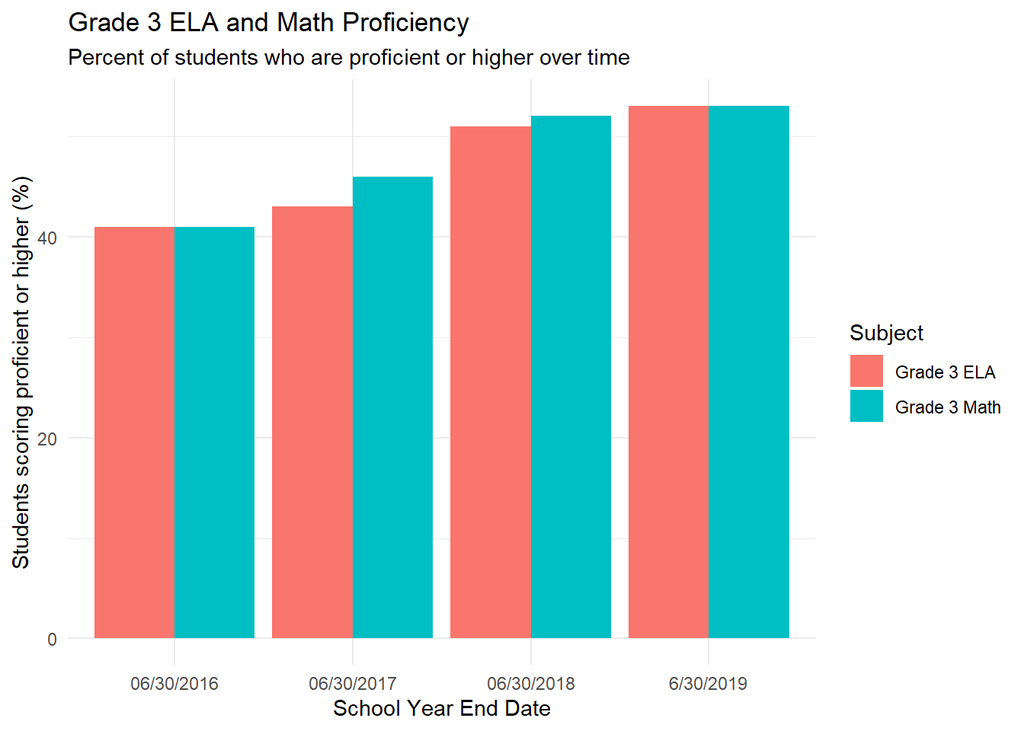

```r
# convert proficiency level variable to numeric
nyc_15t19_numeric <- nyc_15t19 %>% mutate(L1_PCT = as.numeric(gsub("%", "", L1_PCT)),
         L2_PCT = as.numeric(gsub("%", "", L2_PCT)),
         L3_PCT = as.numeric(gsub("%", "", L3_PCT)),
         L4_PCT = as.numeric(gsub("%", "", L4_PCT)),
         `L3-L4_PCT` = as.numeric(gsub("%", "", `L3-L4_PCT`)),
         )

ggplot(

  # isolate dataset to NYC and grade 3
  nyc_15t19_numeric %>% filter(NAME == "NRC - NYC" & SUBGROUP_NAME == "All Students" & grepl("Grade 3", ITEM_DESC)),

  aes(x = SY_END_DATE, y = `L3-L4_PCT`, fill = ITEM_DESC)) + geom_bar(stat = "identity", position = "dodge") + labs (title = "Grade 3 ELA and Math Proficiency", subtitle = "Percent of students who are proficient or higher over time") + xlab("School Year End Date") + ylab("Students scoring proficient or higher (%)") + guides(fill=guide_legend(title="Subject")) + theme_minimal()
```

Test score proficiency seems to be increasing over time. I’m now going to map the change between the 2015-16 school year and the 2018-19 school year in these two levels of proficiency.

## Difference in proficiency from 2015-16 to 2018-19

```r
# create difference variable
spatial_scores2 <- spatial_scores %>%

  # convert l3-l4

  mutate(diff = `L3-L4_PCT_6/30/2019` - `L3-L4_PCT_06/30/2016`)

# peek to make sure new variable was created correctly
spatial_scores2 %>% select(`L3-L4_PCT_6/30/2019`, `L3-L4_PCT_06/30/2016`, diff)
```

```
## Simple feature collection with 43450 features and 3 fields (with 2147 geometries empty)
## Geometry type: GEOMETRY
## Dimension:     XY
## Bounding box:  xmin: -74.25577 ymin: 40.49599 xmax: -73.70002 ymax: 40.91544
## Geodetic CRS:  WGS 84
## First 10 features:
##    L3-L4_PCT_6/30/2019 L3-L4_PCT_06/30/2016 diff                       geometry
## 1                   20                   22   -2 POLYGON ((-74.0058 40.58181...
## 2                   29                   18   11 POLYGON ((-74.0058 40.58181...
## 3                   10                   26  -16 POLYGON ((-74.0058 40.58181...
## 4                   17                   22   -5 POLYGON ((-74.0058 40.58181...
## 5                   21                   15    6 POLYGON ((-74.0058 40.58181...
## 6                   NA                   NA   NA POLYGON ((-74.0058 40.58181...
## 7                   NA                   NA   NA POLYGON ((-74.0058 40.58181...
## 8                   NA                   NA   NA POLYGON ((-74.0058 40.58181...
## 9                   23                   28   -5 POLYGON ((-74.0058 40.58181...
## 10                  17                    8    9 POLYGON ((-74.0058 40.58181...
```

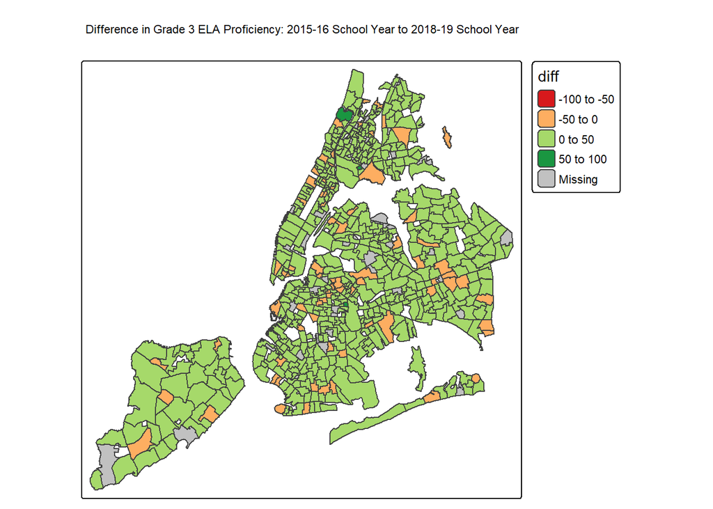

```r
# create ela map
ela_diff_map <- tm_shape(spatial_scores2 %>% filter(grepl("Grade 3 ELA", ITEM_DESC))) + tm_polygons(col = "diff", palette = "RdYlGn") + tm_title("Difference in Grade 3 ELA Proficiency: 2015-16 School Year to 2018-19 School Year")

ela_diff_map
```

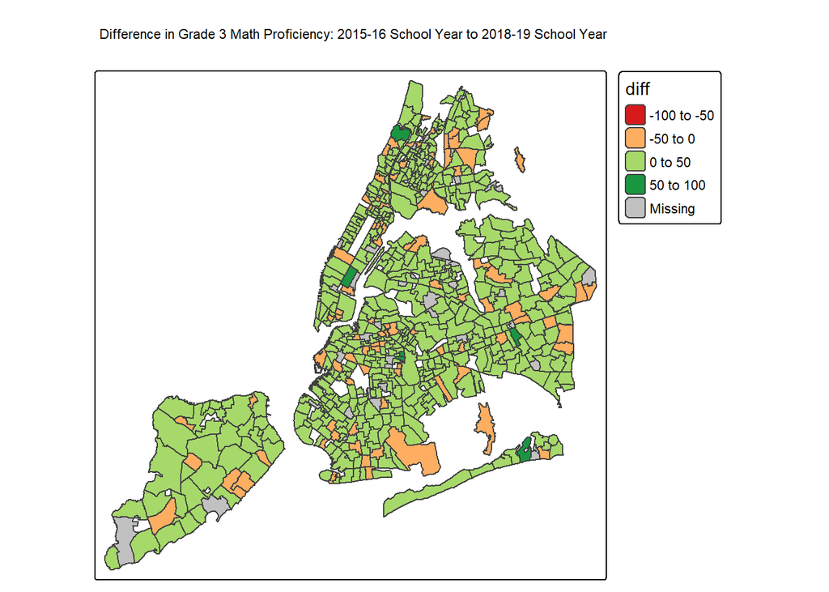

```r
# create math map
math_diff_map <- tm_shape(spatial_scores2 %>% filter(grepl("Grade 3 Math", ITEM_DESC))) + tm_polygons(col = "diff", palette = "RdYlGn") + tm_title("Difference in Grade 3 Math Proficiency: 2015-16 School Year to 2018-19 School Year")

math_diff_map
```

Finally, I’m going to visualize the scores for NYC and the state as a whole.

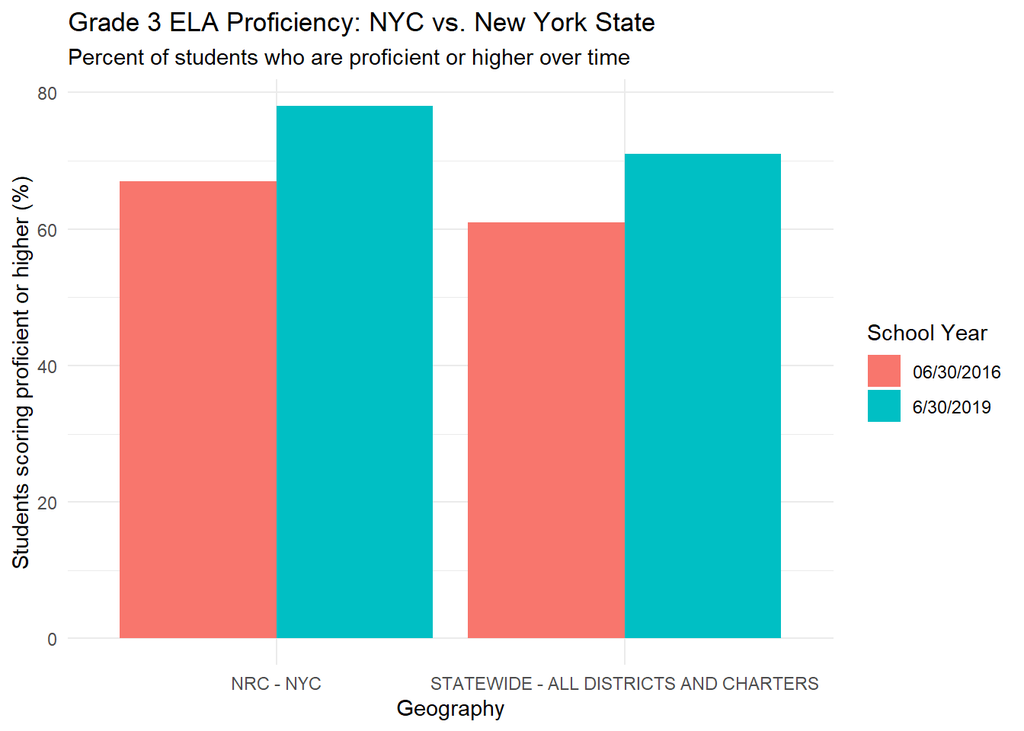

```r
# ELA
ggplot(

  # isolate dataset to 2015-16 and 2018-19 school years, NYC, NY state, and Grade 3
  nyc_15t19_numeric %>% filter(SY_END_DATE %in% c("06/30/2016", "6/30/2019") & NAME %in% c("NRC - NYC", "STATEWIDE - ALL DISTRICTS AND CHARTERS") & grepl("Grade 3 ELA", ITEM_DESC)),
  aes(x = NAME, y = `L3-L4_PCT`, fill = SY_END_DATE)) + geom_bar(stat = "identity", position = "dodge") + labs (title = "Grade 3 ELA Proficiency: NYC vs. New York State", subtitle = "Percent of students who are proficient or higher over time") + xlab("Geography") + ylab("Students scoring proficient or higher (%)") + guides(fill=guide_legend(title="School Year")) + theme_minimal()
```

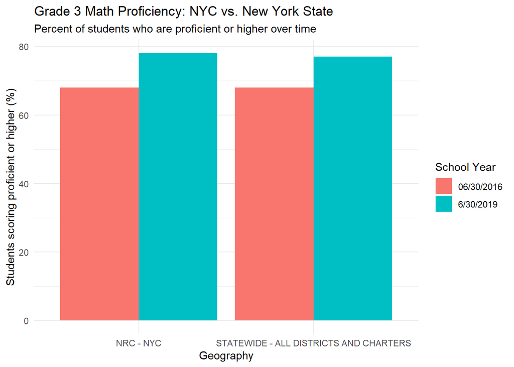

```r
# Math
ggplot(

  # isolate dataset to 2015-16 and 2018-19 school years, NYC, NY state, and Grade 3
  nyc_15t19_numeric %>% filter(SY_END_DATE %in% c("06/30/2016", "6/30/2019") & NAME %in% c("NRC - NYC", "STATEWIDE - ALL DISTRICTS AND CHARTERS") & grepl("Grade 3 Math", ITEM_DESC)),
  aes(x = NAME, y = `L3-L4_PCT`, fill = SY_END_DATE)) + geom_bar(stat = "identity", position = "dodge") + labs (title = "Grade 3 Math Proficiency: NYC vs. New York State", subtitle = "Percent of students who are proficient or higher over time") + xlab("Geography") + ylab("Students scoring proficient or higher (%)") + guides(fill=guide_legend(title="School Year")) + theme_minimal()
```

For both geographies, the difference over time seems pretty similar. I’ll find out how it actually is in my difference-in-differences modeling below.

# Model

First, I’m going to conduct two t-tests to see if there’s a meaningful difference in scores between the 2015-16 school year and the 2018-19 school year in ELA and math scores for 3rd graders in NYC.

```r
# create dataset for ela t-test
ela_ttest_ds <- nyc_15t19_pivot %>% filter(NAME != "STATEWIDE - ALL DISTRICTS AND CHARTERS" & ITEM_DESC=="Grade 3 ELA")

# run ela t-test
ela_ttest <- t.test(ela_ttest_ds$`L3-L4_PCT_6/30/2019`, ela_ttest_ds$`L3-L4_PCT_06/30/2016`)

# create dataset for math t-test
math_ttest_ds <- nyc_15t19_pivot %>% filter(NAME != "STATEWIDE - ALL DISTRICTS AND CHARTERS" & ITEM_DESC=="Grade 3 Math")

# run ela t-test
math_ttest <- t.test(math_ttest_ds$`L3-L4_PCT_6/30/2019`, math_ttest_ds$`L3-L4_PCT_06/30/2016`)


ela_ttest
```

```
##
##  Welch Two Sample t-test
##
## data:  ela_ttest_ds$`L3-L4_PCT_6/30/2019` and ela_ttest_ds$`L3-L4_PCT_06/30/2016`
## t = 41.027, df = 21005, p-value < 2.2e-16
## alternative hypothesis: true difference in means is not equal to 0
## 95 percent confidence interval:
##  12.39366 13.63728
## sample estimates:
## mean of x mean of y
##  53.49229  40.47681
```

```r
math_ttest
```

```
##
##  Welch Two Sample t-test
##
## data:  math_ttest_ds$`L3-L4_PCT_6/30/2019` and math_ttest_ds$`L3-L4_PCT_06/30/2016`
## t = 37.651, df = 20775, p-value < 2.2e-16
## alternative hypothesis: true difference in means is not equal to 0
## 95 percent confidence interval:
##  11.89386 13.20022
## sample estimates:
## mean of x mean of y
##  53.93694  41.38990
```

Both t-tests indicate a statistically significant difference in the percent of students who are proficient or above between the 2015-16 school year and the 2018-19 school year. However, this could be the result of a statewide trend. I’m next going to run a difference-in-differences regression to see if this same trend occurred in the state as a whole or if it’s reasonable to conclude that these improved test scores are a result of Pre-K for All.

```r
# create a variable for treatment group (in this case, treatment group is NYC) and time variable (pre 2018 vs. post 2018)
nyc_15t19_numeric2 <- nyc_15t19_numeric %>%
  mutate(treatment = ifelse(NAME == "STATEWIDE - ALL DISTRICTS AND CHARTERS", 0, 1),
         time = ifelse(SY_END_DATE == "6/30/2019", 1, 0))

# check creation of these variables
nyc_15t19_numeric2 %>% count(treatment, NAME) %>% arrange(treatment)
```

```
## # A tibble: 1,035 × 3
##    treatment NAME                                                         n
##        <dbl> <chr>                                                    <int>
##  1         0 STATEWIDE - ALL DISTRICTS AND CHARTERS                     148
##  2         1 30TH AVENUE SCHOOL (THE)                                    26
##  3         1 30TH AVENUE SCHOOL (THE) (G & T CITYWIDE)                   64
##  4         1 47 AMERICAN SIGN LANGUAGE AND ENGLISH LOWER SCHOOL (THE)    82
##  5         1 ACADEMIC LEADERSHIP CHARTER SCHOOL                         110
##  6         1 ACADEMY FOR EXCELLENCE THROUGH THE ARTS (THE)              112
##  7         1 ACADEMY OF ARTS AND LETTERS                                110
##  8         1 ACADEMY OF TALENTED SCHOLARS (THE)                         118
##  9         1 ACADEMY OF THE ARTS (THE)                                   52
## 10         1 ACADEMY OF THE CITY CHARTER SCHOOL                         126
## # ℹ 1,025 more rows
```

```r
nyc_15t19_numeric2 %>% count(time, SY_END_DATE)
```

```
## # A tibble: 4 × 3
##    time SY_END_DATE     n
##   <dbl> <chr>       <int>
## 1     0 06/30/2016  26086
## 2     0 06/30/2017  26821
## 3     0 06/30/2018  27189
## 4     1 6/30/2019   34766
```

```r
# run regression
did_regression <- lm(`L3-L4_PCT` ~ treatment*time, data = nyc_15t19_numeric2)

summary(did_regression)
```

```
##
## Call:
## lm(formula = `L3-L4_PCT` ~ treatment * time, data = nyc_15t19_numeric2)
##
## Residuals:
##     Min      1Q  Median      3Q     Max
## -53.715 -19.715  -1.715  19.134  54.134
##
## Coefficients:
##                Estimate Std. Error t value Pr(>|t|)
## (Intercept)      42.824      2.475  17.303   <2e-16 ***
## treatment         3.043      2.477   1.228    0.219
## time              5.220      4.439   1.176    0.240
## treatment:time    2.629      4.443   0.592    0.554
## ---
## Signif. codes:  0 '***' 0.001 '**' 0.01 '*' 0.05 '.' 0.1 ' ' 1
##
## Residual standard error: 25 on 87472 degrees of freedom
##   (27386 observations deleted due to missingness)
## Multiple R-squared:  0.02062,    Adjusted R-squared:  0.02059
## F-statistic: 613.9 on 3 and 87472 DF,  p-value: < 2.2e-16
```

This regression model suggests that NYC’s test score increase is not unique and cannot be attributed to Pre-K for all.